# Bure Marshes: a Long-term Monitoring Network report

Kieran Fox

15/02/2021

This is an example of a report to send to site managers. It wouldn’t need to have the author, its just added as default. When these reports are finalised, I will definitely make them more pretty, this is just to give you an idea of the content. This is an HTML report rather than PDF so that the maps can be a little interactive.

# Describing the nvc habitats

```
##                            BAP_BROAD 2010 2014 2019
##  Broadleaved, Mixed and Yew Woodland   19   19   19
##                 Fen, Marsh and Swamp   31   30   33
##                                Total   50   49   52
```

```
##  NVC_groupc 2010 2014 2019
##           M    2    4    4
##           S   43   28   39
##          SD    1   NA   NA
##           W    6   18   10
##       Total   52   50   53
```

This is just to give a simple overview of the habitats in the site. I will obviously look to make these tables look a lot nicer in the final reports.

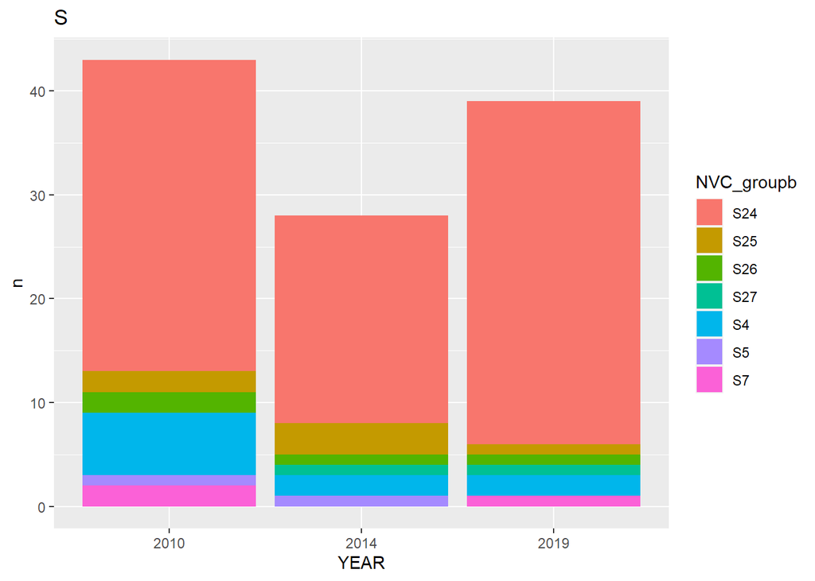

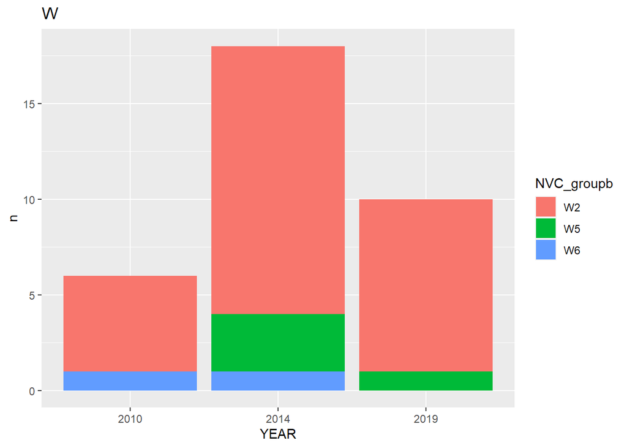

This shows the proportion of each specific nvc habitat in the broader habitats. in these case we can see no interesting information and so we would likely remove these. There are examples of sites where there is a clear change in the proportion of the more specific nvc habitats and as these designations often give an indication of habitat quality those could be useful. For example CG2 is much higher quality grassland than CG6

# Describing the species richness and diversity

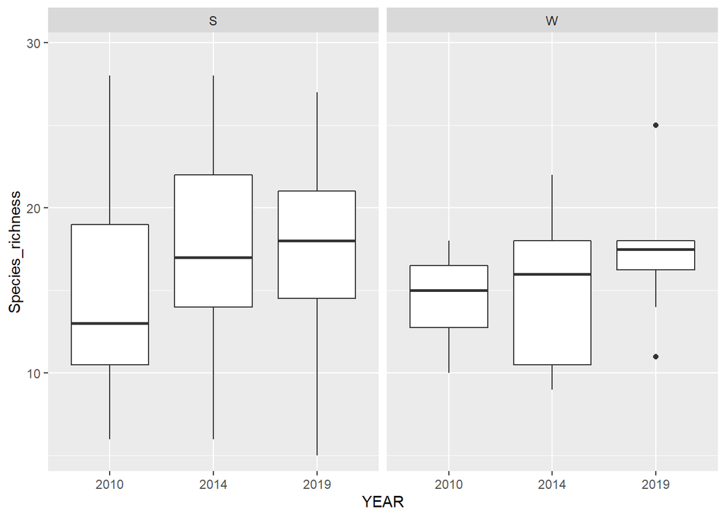

[interactive chart not shown]

Something I would really like to do is have maps that can switch between plotting two different features. In this case, switching between species richness and species diversity would be ideal. I’m actually not sure if this is possible. I will look into it. therwise we would just have two different plots.

[interactive chart not shown]

the same map can be shown using BAP BROAD habitats as well. Probably we would decide which is the most informative

[interactive chart not shown]

This shows the change in the last survey. There is not a huge spatial relationship in the change in species richness but to me it appears there might be a slight concentrated increase in the centre of the site. We would need to decide if we wanted to include this figure.

# Ellenberg and grimes

This section will be to see how ellenberg and grimes scores have changed and if there is a spatial relationship to the change. We can remove these difures for any particular score if there is no change and we can remove just the map figures if the change is not spatially related

### Fertility change by year

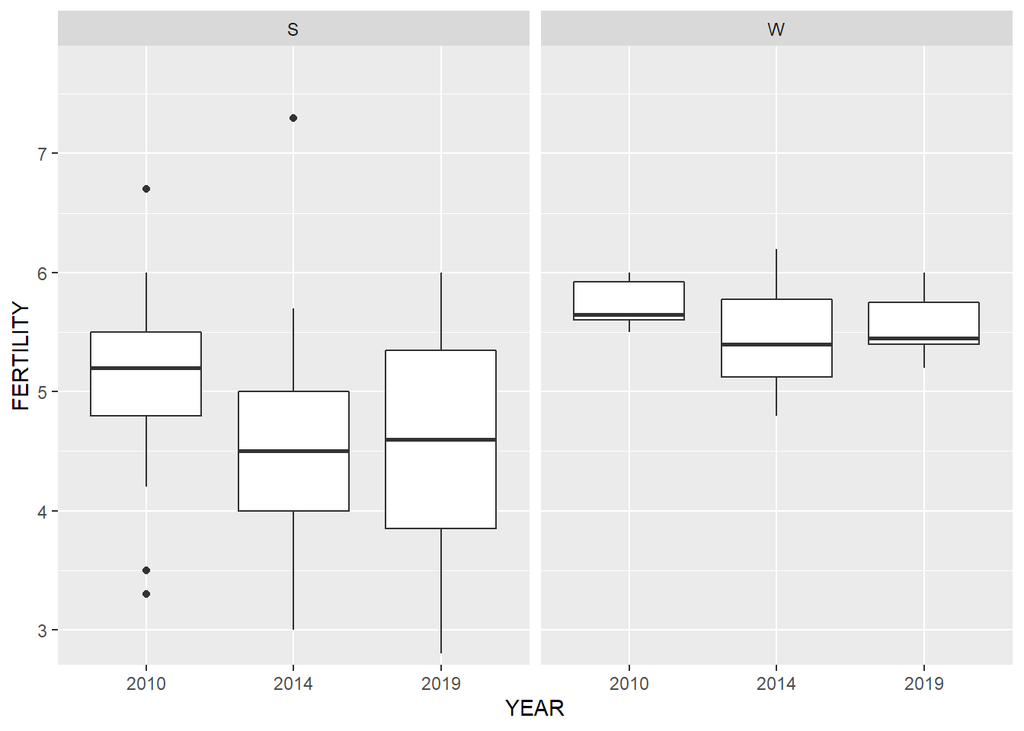

In this example we can see a definite decrease in fertility between 2010 and 2014 which suggests we should keep this figure

### Fertility across the site

[interactive chart not shown]

This figure shows there is a slight spatial relationship to fertility across the site. It might be interesting to the site manager

### Fertility change across the site

[interactive chart not shown]

This is a figure of change between 2010 and 2014. It looks like a particular reduction of fertility in the center of the site. This could be related to the change in species richness in that same area. (It is worth baring in mind that these ellenberg scores are in part calculated from the species richness value so this can explain the relationship. More detailed soil data would be needed to investigate if there is a real cause and effect relationship).

[interactive chart not shown]